# Finding Similarities in a Graph

Similarity between entities falls out naturally from the relationships they share. This post uses Cypher to find playlists that overlap, then ranks them by how many tracks they share and how closely those tracks line up.

graph-rag

neo4j

LLM

Author

Mei-Chin Pang

Published

August 15, 2026

# Finding Similarities in a Graph

One of the strengths of a graph model is that similarity between entities emerges naturally from shared relationships. If two playlists both contain the same track *in the same slot*, that is a strong hint that they were built with a similar intent. The Cypher query below surfaces exactly those overlaps.

```
MATCH path=(n:Playlist)-[r1:HAS_TRACK]->(track)<-[r2:HAS_TRACK]-(
  other:Playlist)
WHERE r1.position = r2.position
RETURN path
LIMIT 5;
```

## Reading the query

- `MATCH path=(n:Playlist)-[r1:HAS_TRACK]->(track)<-[r2:HAS_TRACK]-(other:Playlist)` describes a *path* in which a `Playlist` node `n` points to a `track` through a `HAS_TRACK` relationship `r1`, and a second `Playlist` node `other` points to the **same** `track` through its own `HAS_TRACK` relationship `r2`. Because both arrows converge on the shared `track`, the pattern only matches tracks that appear in more than one playlist.
- `WHERE r1.position = r2.position` tightens the match. `HAS_TRACK` stores the track’s slot within each playlist in a `position` property, so this filter keeps only the cases where the track sits at the *same* position in both playlists, which is a much stronger signal of similarity than merely sharing a track.
- `RETURN path` returns the whole matched pattern (both playlists, the track, and the two relationships) rather than a single column, which lets the Neo4j Browser render it visually as a graph.
- `LIMIT 5` caps the output at five paths so the result stays readable while exploring.

Note that this pattern is symmetric: it also matches a playlist with itself (`n` and `other` bound to the same node) and returns each pair twice (once as `n`–`other` and once as `other`–`n`). Adding `WHERE ... AND id(n) < id(other)` would remove those mirror duplicates if needed.

## The result

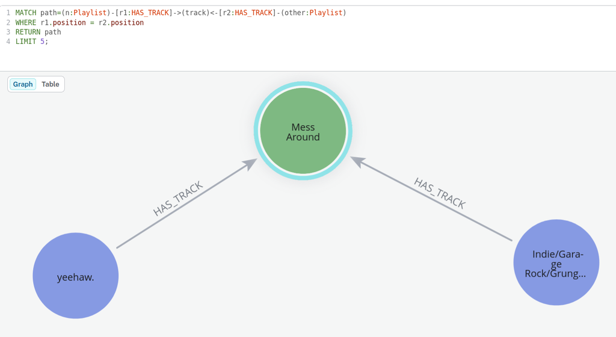

Two playlists that share the track *Mess Around* at the same position.

The graph view returns a single path made up of three nodes and two relationships:

- The central green node is the shared `track`, **Mess Around**.
- The two blue nodes are the playlists that both contain it:`yeehaw.` on the left and `Indie/Garage Rock/Grunge…` on the right.
- Each `HAS_TRACK` arrow points from a playlist into the track, and the `WHERE r1.position = r2.position` filter guarantees that *Mess Around* occupies the identical slot in both playlists.

Even though the two playlists carry very different names and genres, the query reveals a concrete link between them: they both place *Mess Around* in the same position. Repeating this pattern across the whole dataset is the basis for recommendation-style queries such as “playlists similar to this one” or “tracks that tend to appear together”, all expressed directly as graph traversals instead of expensive joins.

# Ranking the Most Similar Playlists

The previous query inspects one shared track at a time. To actually *rank* playlists by how much they overlap, we need to aggregate all the tracks a pair shares and then measure how many of them line up at the same position. The query below does exactly that.

```
// find playlists sharing tracks
MATCH path=(p:Playlist)-[r1:HAS_TRACK]->(track)<-[r2:HAS_TRACK]-(
  other:Playlist)
WITH
    p AS playlistLeft,
    other AS playlistRight,
    // collect the track and left, right positions
    collect(
        {
            track: track,
            positionLeft: r1.position,
            positionRight: r2.position
        }
    ) AS commonTracks
// omit if they don't share at least 5 tracks
WHERE size(commonTracks) > 5
RETURN
    playlistLeft.name,
    playlistRight.name,
    size([track in commonTracks
      WHERE track.positionLeft = track.positionRight])
      AS tracksWithSamePosition,
    size([track in commonTracks
      WHERE NOT track.positionLeft = track.positionRight])
      AS tracksAtDifferentPosition
ORDER BY tracksWithSamePosition DESC
LIMIT 100;
```

## Breaking it down part by part

**1. Match every shared track between two playlists**

```
MATCH path=(p:Playlist)-[r1:HAS_TRACK]->(track)<-[r2:HAS_TRACK]-(other:Playlist)
```

This is the same convergent pattern as before: playlist `p` and playlist `other` both point to the same `track`. Crucially, there is **no** `position` filter here, so it captures *every* track two playlists have in common, regardless of where each one sits. Each row produced by the `MATCH` represents one shared track together with its two relationships `r1` and `r2`.

**2. Aggregate the shared tracks into a list with `WITH` + `collect`**

```
WITH
    p AS playlistLeft,
    other AS playlistRight,
    collect(
        {track: track, positionLeft: r1.position, positionRight: r2.position}
    ) AS commonTracks
```

The `WITH` clause groups the rows by the two playlists (`p` and `other`, renamed to `playlistLeft` and `playlistRight` for readability). Whatever is *not* an aggregate becomes the grouping key, so Cypher collapses all the rows for a given playlist pair into a single row. `collect(...)` then gathers every shared track into a list called `commonTracks`, where each element is a small map recording the `track` itself and its `position` in each playlist (`positionLeft` from `r1`, `positionRight` from `r2`).

**3. Keep only meaningfully overlapping pairs**

```
WHERE size(commonTracks) > 5
```

`size(commonTracks)` is the number of tracks the two playlists share. This filter discards pairs with five or fewer common tracks so the result focuses on genuinely similar playlists rather than incidental single-track overlaps.

**4. Compute the similarity metrics with list comprehensions**

```
RETURN
    playlistLeft.name,
    playlistRight.name,
    size([track in commonTracks
      WHERE track.positionLeft = track.positionRight])
      AS tracksWithSamePosition,
    size([track in commonTracks
      WHERE NOT track.positionLeft = track.positionRight])
      AS tracksAtDifferentPosition
```

Each `[track in commonTracks WHERE ...]` is a **list comprehension** that filters the collected list, and wrapping it in `size(...)` counts how many elements survive:

- `tracksWithSamePosition` counts shared tracks whose `positionLeft` equals `positionRight`: tracks in the *same slot* in both playlists.
- `tracksAtDifferentPosition` counts the rest: shared tracks that appear in *different slots*.

Together the two columns describe both *how much* two playlists overlap and *how aligned* that overlap is.

**5. Order and cap the output**

```
ORDER BY tracksWithSamePosition DESC
LIMIT 100;
```

Results are sorted so the most tightly aligned pairs (most tracks in identical positions) come first, and `LIMIT 100` keeps the report to the top 100 pairs.

## The result

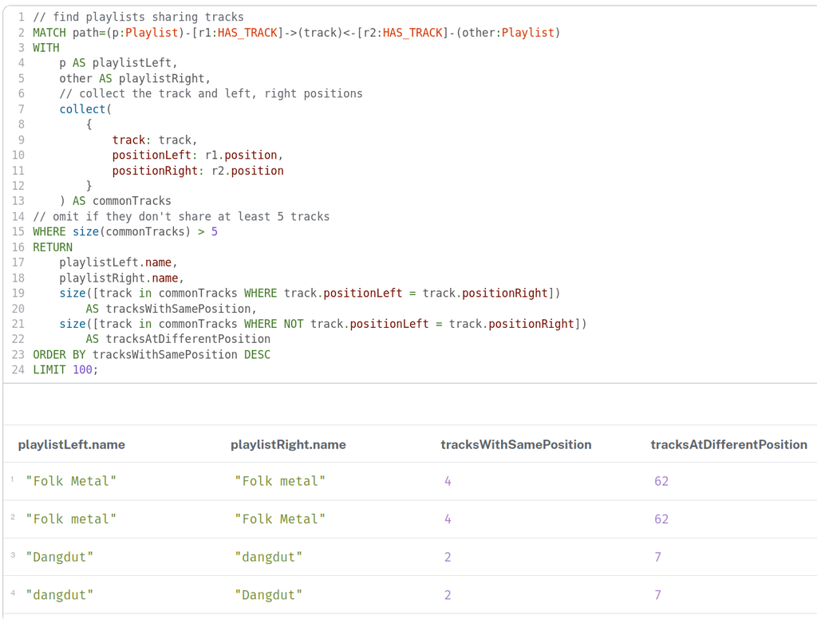

Top playlist pairs ranked by shared tracks and positional alignment.

The table returns one row per playlist pair, ranked by `tracksWithSamePosition`:

- The top two rows are **“Folk Metal”** and **“Folk metal”** (essentially the same playlist under two different capitalisations). They share **66** tracks in total (4 at the same position plus 62 at different positions), which strongly suggests they are duplicates or forks of one another.
- Because the pattern is symmetric, each pair appears twice with `left` and `right` swapped (rows 1 and 2, rows 3 and 4). The metrics are identical in both directions, confirming the counts are order-independent.
- The **“Dangdut”** / **“dangdut”** pair lower down shares far fewer tracks (2 aligned, 7 misaligned), so it ranks below the folk-metal pair even though it is also a near-duplicate name.

Notice that a high `tracksAtDifferentPosition` relative to `tracksWithSamePosition` (62 vs 4 for the folk-metal pair) tells us the two playlists contain almost the same music but in a *reshuffled order*, a subtle distinction that would be invisible if we only counted shared tracks. This kind of ranked, position-aware overlap is precisely what powers “playlists like this” recommendations directly from the graph.

# Persisting Similarity as a Relationship

So far the similarity scores have only existed in query results. A more useful approach is to *write them back into the graph* as a dedicated `SIMILAR` relationship, so future queries can traverse similarity directly instead of recomputing it every time. The query below does exactly that.

```
// find playlists sharing tracks.cypher
MATCH path=(p:Playlist)-[r1:HAS_TRACK]->(track)<-[r2:HAS_TRACK]-(
  other:Playlist)

WITH
    p AS playlistLeft,
    other AS playlistRight,
    // collect the track and left, right positions
    collect(
        {
            track: track,
            positionLeft: r1.position,
            positionRight: r2.position
        }
    ) AS commonTracks

// omit if they don't share at least 5 tracks
WHERE size(commonTracks) > 5

WITH
    playlistLeft,
    playlistRight,
    size([track in commonTracks
        WHERE track.positionLeft = track.positionRight])
        AS tracksWithSamePosition,
    size([track in commonTracks
        WHERE NOT track.positionLeft = track.positionRight])
        AS tracksAtDifferentPosition

MERGE (playlistLeft)-[r:SIMILAR]->(playlistRight)

SET
    r.samePosition = tracksWithSamePosition,
    r.notSamePosition = tracksAtDifferentPosition;
```

## Breaking it down part by part

**1-3. Match, aggregate, and filter (unchanged)**

The first three stages are identical to the ranking query in Ranking the Most Similar Playlists:

- the convergent `MATCH` finds every track two playlists share,
- the first `WITH` + `collect` groups those rows per playlist pair into a `commonTracks` list, and
- `WHERE size(commonTracks) > 5` drops pairs with too little overlap.

See that section for the full explanation of these steps.

**4. Reshape into similarity metrics with a second `WITH`**

```
WITH
    playlistLeft,
    playlistRight,
    size([track in commonTracks
      WHERE track.positionLeft = track.positionRight])
      AS tracksWithSamePosition,
    size([track in commonTracks
      WHERE NOT track.positionLeft = track.positionRight])
      AS tracksAtDifferentPosition
```

This is the same pair of list comprehensions used in the earlier `RETURN`, but here they feed a second `WITH` instead of ending the query. The difference matters: `WITH` keeps the pipeline open, carrying `playlistLeft`, `playlistRight`, and the two counts forward so the next clause can *act* on them rather than just report them.

**5. Create (or reuse) the `SIMILAR` relationship with `MERGE`**

```
MERGE (playlistLeft)-[r:SIMILAR]->(playlistRight)
```

`MERGE` is the match-first-then-create clause: if a `SIMILAR` relationship already exists between this pair it is reused, otherwise a new one is created. Using `MERGE` here (rather than `CREATE`) makes the query **idempotent**, you can re-run it as the data changes without piling up duplicate similarity edges.

**6. Store the scores as relationship properties with `SET`**

```
SET
    r.samePosition = tracksWithSamePosition,
    r.notSamePosition = tracksAtDifferentPosition;
```

Finally `SET` writes the two counts onto the new relationship `r` as the properties `samePosition` and `notSamePosition`. The similarity is now a first-class part of the graph: a query like `MATCH (p:Playlist)-[:SIMILAR]->(q) RETURN q` retrieves related playlists in a single hop, with the alignment scores available for ranking, no re-aggregation required.

# Visualising the Similarity Network

Once the `SIMILAR` relationships have been written to the graph, exploring them becomes trivial. The query below simply asks for those edges and lets the Browser draw the resulting network.

```
MATCH path=(playlist1)-[:SIMILAR]-(playlist2)
RETURN path
LIMIT 100
```

## Reading the query

- `MATCH path=(playlist1)-[:SIMILAR]-(playlist2)` matches any two playlists connected by a `SIMILAR` relationship. Unlike the earlier queries, there is no `HAS_TRACK` traversal or aggregation here. The hard work of computing similarity was already done and persisted, so this is a single, cheap hop.
- The relationship is written **without an arrow direction** (`-[:SIMILAR]-` rather than `->`). This makes the match undirected, so a pair is found regardless of which playlist was stored as the source or target.
- `RETURN path` returns the whole matched pattern so it renders as a graph, and `LIMIT 100` caps the number of relationships drawn.

## The result

[figure not shown]

The `SIMILAR` network, with hub playlists that many others resemble.

Instead of a single pair, the Browser now shows a whole **similarity network**:

- Each blue node is a playlist and each `SIMILAR` edge means the two playlists share more than five tracks (the threshold set when the relationships were built).
- Some playlists act as **hubs**, for example *Electro-popunk…* sits at the centre of many incoming `SIMILAR` edges, meaning a lot of other playlists resemble it. These hubs are natural anchors for “if you like this, try these” recommendations.
- Smaller clusters also emerge, such as the *Beach house* → *Kygo & Friends* → *Chill Deep House* grouping on the left, which hangs together as a recognisable sub-genre neighbourhood.

Because similarity now lives in the graph as explicit edges, this entire view is produced by one short traversal rather than the multi-stage aggregation used to compute it. That is the payoff of persisting derived relationships: the expensive analysis runs once, and every later exploration is a fast walk over the stored network.

# Inspecting a Single Playlist

Before building a recommendation, it helps to look at the playlist we are recommending *for*. A single-line `MATCH` retrieves it by name.

```
// For a given Playlist
MATCH (p:Playlist) WHERE p.name = "all that jazz"
RETURN p
```

## Reading the query

- `MATCH (p:Playlist) WHERE p.name = "all that jazz"` finds the one `Playlist` node whose `name` property equals *all that jazz*.
- `RETURN p` returns that node. Although the query only asks for the playlist itself, the Neo4j Browser expands a returned node to show its immediate relationships, which is why the surrounding tracks appear in the graph view.

## The result

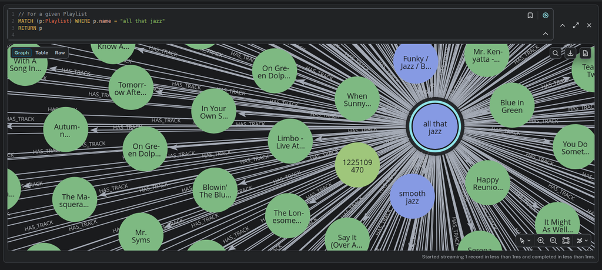

The *all that jazz* playlist and the tracks it links to via `HAS_TRACK`.

The blue node in the centre is the *all that jazz* playlist, surrounded by the green `Track` nodes it points to through `HAS_TRACK` relationships, songs such as *Blowin’ The Blu…*, *When Sunny…*, and *Blue in Green*. Two other blue `Playlist` nodes, *smooth jazz* and *Funky / Jazz / B…*, also appear because they are connected to *all that jazz* by the `SIMILAR` edges built in Persisting Similarity as a Relationship.

This view is essentially a snapshot of everything the recommendation query has to work with: the playlist’s own tracks (to exclude), and the similar playlists (to draw suggestions from). With that context in place, the next section walks through generating the actual recommendations.

# Finding the Last Track

The recommendation query keys off a playlist’s *last* track. There is a neat way to isolate it directly in the `WHERE` clause, without collecting and slicing the whole list.

```
// Find the last track
MATCH (p)-[r:HAS_TRACK]->(t)
WHERE r.position = COUNT {(p)-[:HAS_TRACK]->()}
RETURN t;
```

## Reading the query

- `MATCH (p)-[r:HAS_TRACK]->(t)` walks every `HAS_TRACK` relationship from a playlist `p` to a track `t`, exposing the `position` property on `r` ( the same property introduced in Finding Similarities in a Graph).
- `COUNT {(p)-[:HAS_TRACK]->()}` is a **`COUNT` subquery**: for each playlist it counts how many tracks that playlist has. Since positions run sequentially up to the total number of tracks, this count equals the position of the final track.
- `WHERE r.position = COUNT {...}` therefore keeps only the relationship whose position matches the track count, i.e. the very last track in each playlist.
- `RETURN t` returns those last tracks.

This is a more compact alternative to the `head`/`tail` approach used in Recommending the Next Track: instead of collecting all tracks in reverse order and taking the head, it computes the last position inline and filters straight to it.

## The result

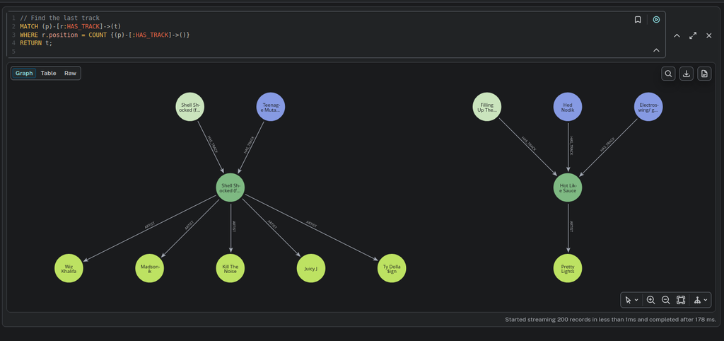

The last track of each playlist, with its artists shown by expansion.

Each green node in the middle row, for example *Shell Shocked* and *Hot Like Sauce*, is the final track of a playlist, matched because its `position` equals that playlist’s total track count. The blue `Playlist` nodes above them are the playlists that end on those tracks, and the lower green nodes (*Wiz Khalifa*, *Ty Dolla $ign*, *Pretty Lights*, …) are the artists the Browser reveals when it expands each returned track through its `ARTIST` relationships.

# Recommending the Next Track

The pieces are now in place for an actual recommendation: given a playlist, look at its last track, hop to *similar* playlists that also contain that track, and suggest tracks from those playlists that the listener does not already have. The query below assembles that pipeline.

```
// find_10_most_popular_tracks_and_recommend.cypher
WITH COLLECT {
    MATCH (popularTrack:Track)-[:HAS_TRACK]-(:Playlist)
    WITH popularTrack, count(*) as playlistCount
    ORDER BY playlistCount DESC
    LIMIT 10
    RETURN popularTrack
} AS popularTracks

// For a given Playlist
MATCH (p:Playlist) WHERE p.name = "all that jazz"

// Collect the tracks in reverse position
WITH p, popularTracks,
COLLECT {
    MATCH (p)-[r:HAS_TRACK]->(t)
    WITH t, r
    ORDER BY r.position DESC
    RETURN t
} AS playlistTracks

WITH
    p AS playlist,
    popularTracks,
    head(playlistTracks) AS lastTrack,
    tail(playlistTracks) AS previousTracks


// Find other playlists that have the same the last track
MATCH (lastTrack)<-[:HAS_TRACK]-(otherPlaylist)-[:SIMILAR]-(playlist)
WHERE otherPlaylist <> playlist

// Find other tracks which are not in the given playlist
MATCH (otherPlaylist)-[:HAS_TRACK]->(recommendation)
WHERE NOT recommendation IN previousTracks
AND NOT recommendation IN popularTracks

// Score them by how frequently they appear
RETURN recommendation.id as recommendedTrackId,
recommendation.name AS recommendedTrack,
otherPlaylist.name AS fromPlaylist,
count(*) AS score
ORDER BY score DESC
LIMIT 10
```

## Breaking it down part by part

**1. Precompute the 10 most popular tracks with `COLLECT { ... }`**

```
WITH COLLECT {
    MATCH (popularTrack:Track)-[:HAS_TRACK]-(:Playlist)
    WITH popularTrack, count(*) as playlistCount
    ORDER BY playlistCount DESC
    LIMIT 10
    RETURN popularTrack
} AS popularTracks
```

`COLLECT { ... }` is a **subquery expression**: it runs a full nested query and gathers its results into a list. Inside, the pattern counts how many playlists each track appears in (`count(*)`), orders by that count, and keeps the top 10. The outcome is a `popularTracks` list that later stages use as an *exclusion* set. Very popular tracks are poor recommendations precisely because everyone already has them.

**2. Select the target playlist**

```
MATCH (p:Playlist) WHERE p.name = "all that jazz"
```

A straightforward `MATCH` pins the query to a single playlist by name. This is the playlist we want recommendations *for*.

**3. Collect the playlist’s tracks in reverse position order**

```
WITH p, popularTracks,
COLLECT {
    MATCH (p)-[r:HAS_TRACK]->(t)
    WITH t, r
    ORDER BY r.position DESC
    RETURN t
} AS playlistTracks
```

Another `COLLECT { ... }` subquery gathers the playlist’s tracks, this time ordered by `r.position` **descending** so the most recently added track comes first. `popularTracks` is carried through untouched. This reuses the `position` property on `HAS_TRACK` introduced in Finding Similarities in a Graph.

**4. Split the list into the last track and the rest with `head` / `tail`**

```
WITH
    p AS playlist,
    popularTracks,
    head(playlistTracks) AS lastTrack,
    tail(playlistTracks) AS previousTracks
```

Because the list is in reverse order, `head(playlistTracks)` is the **last** track the listener added. The “current context” for the recommendation and `tail(playlistTracks)` is everything else, kept as `previousTracks` so those can be excluded later.

**5. Hop to similar playlists that share the last track**

```
MATCH (lastTrack)<-[:HAS_TRACK]-(otherPlaylist)-[:SIMILAR]-(playlist)
WHERE otherPlaylist <> playlist
```

This is the heart of the recommendation. It combines two hops: `otherPlaylist` must both **contain the last track** (`lastTrack<-[:HAS_TRACK]-otherPlaylist`) *and* be linked to our playlist by the `SIMILAR` edge built in Persisting Similarity as a Relationship. The `WHERE otherPlaylist <> playlist` guard stops the playlist from recommending itself. Reusing the stored `SIMILAR` relationship is what keeps this cheap, no similarity is recomputed here.

**6. Gather candidate tracks, minus what the listener already has or knows**

```
MATCH (otherPlaylist)-[:HAS_TRACK]->(recommendation)
WHERE NOT recommendation IN previousTracks
AND NOT recommendation IN popularTracks
```

From each similar playlist, take its tracks as `recommendation` candidates, then filter out anything already in `previousTracks` (the listener has it) or in `popularTracks` (too generic to be a useful suggestion).

**7. Score by frequency and return the top 10**

```
RETURN recommendation.id AS recommendedTrackId,
recommendation.name AS recommendedTrack,
otherPlaylist.name AS fromPlaylist,
count(*) AS score
ORDER BY score DESC
LIMIT 10
```

`count(*)` aggregates how often each candidate appears across the matched similar playlists: the more independent playlists suggest a track, the higher its `score`. Sorting by `score` descending and taking the top 10 yields the final recommendation list, along with the playlist each suggestion came from.

## The result

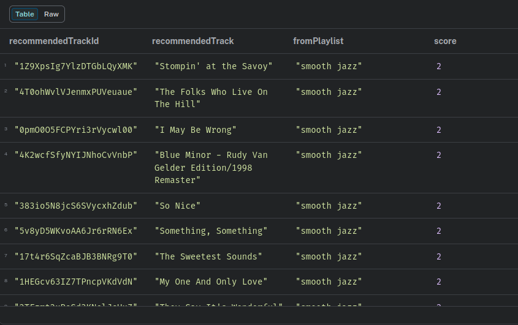

Recommended tracks for the *all that jazz* playlist, sourced from a similar *smooth jazz* playlist.

The query returns a ranked table of suggestions for the *all that jazz* playlist:

- Each row is a `recommendedTrack`, for example *Stompin’ at the Savoy*, *I May Be Wrong*, and *My One And Only Love*, none of which are already in the playlist or in the global top-10 popular tracks.
- The `fromPlaylist` column shows they all surfaced via *smooth jazz*, a playlist connected to *all that jazz* by a `SIMILAR` edge and sharing its last track. This confirms the traversal followed the intended path.
- The `score` of `2` means each track appeared twice across the matched similar playlists. With a small, tightly related neighbourhood the scores are low and close together; on a larger graph this frequency count is what separates strong recommendations from incidental ones.

Taken together, this query shows the whole point of the earlier steps paying off: the precomputed `SIMILAR` relationships turn what would be an expensive multi-join recommendation into a short, readable traversal that produces genuine “you might also like” suggestions.

# Connecting Two Tracks with a Shortest Path

A different question a graph answers well is *how are two tracks related?* Even tracks that never share a playlist directly can be linked through a chain of shared playlists. Cypher’s shortest-path search finds that chain.

```
//find_shortest_path.cypher
MATCH (t1:Track {id: "7ysmJhXFQtiBQlk6EZ6sks"})
MATCH (t2:Track {id:"7N2UmTJG5Uv6zQvjf4eIjd"})

MATCH path = SHORTEST 5 (t1)-[r:HAS_TRACK]-+(t2)

RETURN path
```

## Reading the query

- `MATCH (t1:Track {id: "..."})` and `MATCH (t2:Track {id:"..."})` pin down the two endpoint tracks by their unique `id` property. Matching on `id` (rather than name) guarantees exactly one node each.
- `MATCH path = SHORTEST 5 (t1)-[r:HAS_TRACK]-+(t2)` is the key part:
  - `SHORTEST 5` asks for the five shortest paths between the two tracks, ordered by length.
  - `-[r:HAS_TRACK]-+` is a **variable-length, undirected** pattern. The `+` means “one or more `HAS_TRACK` hops”, and the lack of an arrow lets the path traverse the relationship in either direction: track → playlist → track → playlist …, so it can weave through the shared playlists that connect the two songs.
- `RETURN path` returns the matched paths so the Browser draws them.

Because tracks only connect *through* playlists, every step alternates between a `Track` and a `Playlist`, reusing the same `HAS_TRACK` relationship seen throughout this post, which is read here in both directions rather than just playlist → track.

## The result

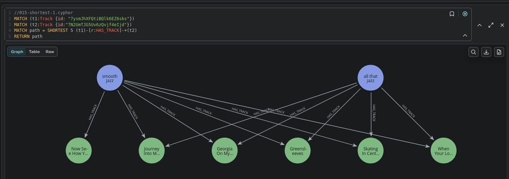

The shortest paths linking two tracks through the playlists they share.

The graph shows the two endpoint tracks connected via the playlists that contain them. The blue `Playlist` nodes *smooth jazz* and *all that jazz* sit at the top, each fanning out through `HAS_TRACK` edges to the green `Track` nodes below (*Now See How Y…*, *Journey Into M…*, *Georgia On My…*, *Greensleeves*, *Skating In Cent…*, *When Your Lo…*). A path hops track → playlist → track, so the two playlists act as the bridges that join the endpoints in just a few steps. Returning several shortest paths at once reveals *how many* independent short connections exist, not just that a single one does, which is a compact way to gauge how closely two tracks are related within the graph.

# All Paths vs. Shortest Paths

It is worth contrasting the shortest-path query with a superficially similar one that returns *every* path within a length bound.

```
//016-shortest-2.cypher
MATCH (t1:Track {id: "7ysmJhXFQtiBQlk6EZ6sks"})
MATCH (t2:Track {id:"7N2UmTJG5Uv6zQvjf4eIjd"})
MATCH p = ((t1)-[*..5]-(t2))
RETURN p
```

## Reading the query

- The two endpoint `MATCH` clauses are identical to Connecting Two Tracks with a Shortest Path: they pin `t1` and `t2` by `id`.
- `MATCH p = ((t1)-[*..5]-(t2))` is the difference. `-[*..5]-` is an **undirected variable-length** pattern meaning “between one and five relationships of any type”, and most importantly there is **no `SHORTEST` keyword**. Without it, Cypher returns **every** path up to length 5, not just the shortest ones.
- `RETURN p` returns all of those paths.

## How it differs from the shortest-path block

|  | `SHORTEST 5 (t1)-[r:HAS_TRACK]-+(t2)` | `(t1)-[*..5]-(t2)` |
| --- | --- | --- |
| Selection | The 5 *shortest* paths | *All* paths |
| Length control | No fixed cap, grows only as needed to find 5 | Hard upper bound of 5 hops |
| Relationship type | Restricted to `HAS_TRACK` | Any relationship type (`HAS_TRACK`, `ARTIST`, `SIMILAR`, …) |
| Result size | Small and bounded (5 paths) | Potentially huge, every route within 5 hops |

In short, the first block asks a *targeted* question (“give me the few closest connections through shared playlists”), while the second asks an *exhaustive* one (“show me everything reachable within five hops”). The exhaustive form is useful for exploring a neighbourhood, but it can return a large, dense result because the number of paths grows quickly with each extra hop.

## The result

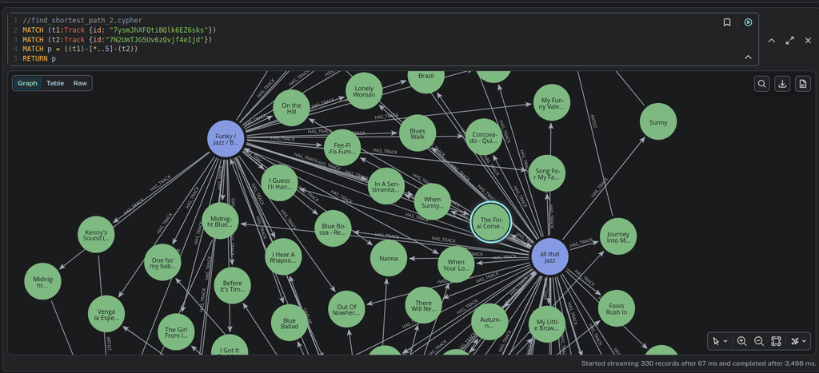

Every path within five hops between the two tracks, producing a dense neighbourhood.

The difference is immediately visible. Rather than a handful of clean bridges, the query streams back **330 records** and fills the view with a dense web of nodes. The two blue `Playlist` hubs: *Funky / Jazz / B…* and *all that jazz*, each fan out through dozens of `HAS_TRACK` edges to green `Track` nodes such as *Lonely Woman*, *Blues Walk*, *Naima*, and *The Final Come…* (one of the highlighted endpoints). Because the pattern accepts any relationship of up to five hops, it captures the entire cluster of tracks reachable through those shared playlists, not just the shortest routes between the two endpoints. This illustrates why `SHORTEST` matters: the same neighbourhood, filtered to the few shortest paths, is far easier to interpret than the full enumeration shown here.

# References

1. Misquitta, L. and Willemsen, C. (2025) *Neo4j: The Definitive Guide: Hands-On Recipes for Production Ready Graph Implementations*. O’Reilly Media.
2. Bratanic, T. and Hane, O., 2025. Essential GraphRAG: Knowledge Graph-Enhanced RAG. Simon and Schuster.